# Scraping data from social media

Pablo Barbera

January 22, 2016

### Scraping web data from Facebook

To scrape data from Facebook’s API, we’ll use the `Rfacebook` package.

```r
#install.packages("Rfacebook")
library(Rfacebook)
```

To get access to the Facebook API, you need an OAuth code. You can get yours going to the following URL: https://developers.facebook.com/tools/explorer

Once you’re there:  
1. Click on “Get Access Token”  
2. Copy the long code (“Access Token”) and paste it here below, substituting the fake one I wrote:

```r
fb_oauth = 'XXXXXXXYYYYYYZZZZZZ11111'
```

Now try running the following line:

```r
getUsers("me", token=fb_oauth, private_info=TRUE)
```

```
##          id          name username first_name middle_name last_name gender
## 1 557698085 Pablo Barberá       NA      Pablo          NA   Barberá   male
##   locale category likes picture   birthday           location
## 1  en_US       NA    NA      NA 01/12/1986 New York, New York
##         hometown relationship_status
## 1 Cáceres, Spain                  NA
```

Does it return your Facebook public information? Yes? Then we’re ready to go. See also `?fbOAuth` for information on how to get a long-lived OAuth token.

```r
page <- getPage("rbloggers", token=fb_oauth, n=200)
```

```
## 100 posts 200 posts
```

What information is available for each of these posts?

```r
page[1,]
```

```
##        from_id  from_name
## 1 191414254890 R bloggers
##                                                                                                 message
## 1 State of the Union Speeches and Data\nhttp://www.r-bloggers.com/state-of-the-union-speeches-and-data/
##               created_time type
## 1 2016-01-21T21:37:58+0000 link
##                                                              link
## 1 http://www.r-bloggers.com/state-of-the-union-speeches-and-data/
##                               id likes_count comments_count shares_count
## 1 191414254890_10153465877969891          32              0            8
```

Which post got more likes, more comments, and more shares?

```r
page[which.max(page$likes_count),]
```

```
##         from_id  from_name
## 57 191414254890 R bloggers
##                                                                                        message
## 57 ggplot2 version 2 is out!!!\nhttp://www.r-bloggers.com/ggplot-2-0-0/\n\n(and some more !!!)
##                created_time type                                    link
## 57 2015-12-21T18:34:36+0000 link http://www.r-bloggers.com/ggplot-2-0-0/
##                                id likes_count comments_count shares_count
## 57 191414254890_10153403687264891         560              7          100
```

```r
page[which.max(page$comments_count),]
```

```
##         from_id  from_name
## 15 191414254890 R bloggers
##                                                                                                                    message
## 15 "R Users Will Now Inevitably Become Bayesians"\nhttp://www.r-bloggers.com/r-users-will-now-inevitably-become-bayesians/
##                created_time type
## 15 2016-01-13T23:06:26+0000 link
##                                                                       link
## 15 http://www.r-bloggers.com/r-users-will-now-inevitably-become-bayesians/
##                                id likes_count comments_count shares_count
## 15 191414254890_10153450341799891         284             10           82
```

```r
page[which.max(page$shares_count),]
```

```
##         from_id  from_name
## 85 191414254890 R bloggers
##                                                                                message
## 85 "How to Learn R" - resources and links\nhttp://www.r-bloggers.com/how-to-learn-r-2/
##                created_time type
## 85 2015-12-10T14:52:19+0000 link
##                                           link
## 85 http://www.r-bloggers.com/how-to-learn-r-2/
##                                id likes_count comments_count shares_count
## 85 191414254890_10153381629049891         465              9          378
```

We can also subset by date. For example, imagine we want to get all the posts from November 2012 on Mitt Rommney’s Facebook page

```r
page <- getPage("mittromney", token=fb_oauth, n=1000,
    since='2012/11/01', until='2012/11/30')
```

```
## 26 posts 39 posts
```

```r
page[which.max(page$likes_count),]
```

```
##       from_id   from_name
## 3 21392801120 Mitt Romney
##                                                                                                                                          message
## 3 From the bottom of our hearts, Ann and I thank you for your support, prayers, efforts, and vote.  We are forever grateful to every one of you.
##               created_time  type
## 3 2012-11-10T19:42:24+0000 photo
##                                                                                                     link
## 3 https://www.facebook.com/mittromney/photos/a.161403756120.123284.21392801120/10151158799556121/?type=3
##                              id likes_count comments_count shares_count
## 3 21392801120_10151158799581121      916442         140968        15414
```

And if we need to, we can also extract the specific comments from each post.

```r
post_id <- page$id[which.max(page$likes_count)]
post <- getPost(post_id, token=fb_oauth, n.comments=1000, likes=FALSE)
```

This is how you can view those comments:

```r
comments <- post$comments
head(comments)
```

```
##             from_id         from_name
## 1   665108873608190       Jacob Gaggo
## 2   809852659025589    Esther Barnett
## 3 10205421892975328   Laurette Murphy
## 4 10154065089520182     Mike Anderson
## 5 10202585187963607        David Rome
## 6   851714951518179 Michael Sowerwine
##                                   message             created_time
## 1                                  u suck 2012-11-10T19:42:39+0000
## 2                          Try again in 4 2012-11-10T19:42:40+0000
## 3                    You're very welcome! 2012-11-10T19:42:42+0000
## 4 Just wish the results were different :( 2012-11-10T19:42:43+0000
## 5                                RECOUNT! 2012-11-10T19:42:44+0000
## 6                                   First 2012-11-10T19:42:46+0000
##   likes_count                         id
## 1           5 10151158799556121_11972106
## 2          43 10151158799556121_11972107
## 3          17 10151158799556121_11972108
## 4          94 10151158799556121_11972110
## 5          87 10151158799556121_11972111
## 6           0 10151158799556121_11972113
```

Also, note that users can like comments! What is the comment that got the most likes?

```r
comments[which.max(comments$likes_count),]
```

```
##             from_id     from_name                                 message
## 4 10154065089520182 Mike Anderson Just wish the results were different :(
##               created_time likes_count                         id
## 4 2012-11-10T19:42:43+0000          94 10151158799556121_11972110
```

### Scraping web data from Twitter

#### Authenticating

Follow these steps to create your token:

1. Go to apps.twitter.com and sign in.
2. Click on “Create New App”. You will need to have a phone number associated with your account in order to be able to create a token.
3. Fill name, description, and website (it can be anything, even http://www.google.com). Make sure you leave ‘Callback URL’ empty.
4. Agree to user conditions.
5. From the “Keys and Access Tokens” tab, copy consumer key and consumer secret and paste below

```r
# install.packages("ROAuth")
library(ROAuth)
requestURL <- "https://api.twitter.com/oauth/request_token"
accessURL <- "https://api.twitter.com/oauth/access_token"
authURL <- "https://api.twitter.com/oauth/authorize"
consumerKey <- "XXXXXXXXXXXX"
consumerSecret <- "YYYYYYYYYYYYYYYYYYY"

my_oauth <- OAuthFactory$new(consumerKey=consumerKey,
  consumerSecret=consumerSecret, requestURL=requestURL,
  accessURL=accessURL, authURL=authURL)
```

Run the below line and go to the URL that appears on screen. Then, type the PIN into the console (RStudio sometimes doesn’t show what you’re typing, but it’s there!)

```r
my_oauth$handshake(cainfo = system.file("CurlSSL", "cacert.pem", package = "RCurl"))
```

Now you can save oauth token for use in future sessions with smappR or streamR. Make sure you save it in a folder where this is the only file.

```r
save(my_oauth, file="~/git/data-science-workshop/scraping/credentials/twitter-token.Rdata")
```

#### Collecting data from Twitter’s Streaming API

Collecting tweets filtering by keyword:

```r
#install.packages("streamR")
library(streamR)
load("~/git/data-science-workshop/scraping/credentials/twitter-token.Rdata")
filterStream(file.name="blizzard-tweets.json", track="blizzard",
    timeout=30, oauth=my_oauth)
```

```
## Capturing tweets...
## Connection to Twitter stream was closed after 30 seconds with up to 48 tweets downloaded.
```

Note the options: - `file.name` indicates the file in your disk where the tweets will be downloaded  
- `track` is the keyword(s) mentioned in the tweets we want to capture. - `timeout` is the number of seconds that the connection will remain open  
- `oauth` is the OAuth token we are using

Once it has finished, we can open it in R as a data frame with the `parseTweets` function

```r
tweets <- parseTweets("blizzard-tweets.json")
```

```
## 23 tweets have been parsed.
```

```r
str(tweets)
```

```
## 'data.frame':    23 obs. of  42 variables:
##  $ text                     : chr  "My #rhyming #kidsbook \"The Lizard Stuck in a #Blizzard\" #childrensbooks #eBook on #Amazon #Kindle https://t.co/1fGaH9rKci" "@HailBossRickie @KING_PABLO__ bet we better leave soon before this blizzard gets here" "RT @UrgentPart2: LOGAN - A1063289 - TO BE DESTR…
##  $ retweet_count            : num  0 0 84 0 1 0 0 0 0 4 ...
##  $ favorited                : logi  FALSE FALSE FALSE FALSE FALSE FALSE ...
##  $ truncated                : logi  FALSE FALSE FALSE FALSE FALSE FALSE ...
##  $ id_str                   : chr  "690394818019737600" "690394819391283200" "690394825129066497" "690394836818595841" ...
##  $ in_reply_to_screen_name  : chr  NA "HailBossRickie" NA "xje_suis_daphx" ...
##  $ source                   : chr  "<a href=\"http://www.Feed140.net\" rel=\"nofollow\">feed_140</a>" "<a href=\"http://twitter.com/download/iphone\" rel=\"nofollow\">Twitter for iPhone</a>" "<a href=\"http://twitter.com/download/android\" rel=\"nofollow\">Twitter for Android</a>" "<a href=\"http…
##  $ retweeted                : logi  FALSE FALSE FALSE FALSE FALSE FALSE ...
##  $ created_at               : chr  "Fri Jan 22 04:45:26 +0000 2016" "Fri Jan 22 04:45:26 +0000 2016" "Fri Jan 22 04:45:27 +0000 2016" "Fri Jan 22 04:45:30 +0000 2016" ...
##  $ in_reply_to_status_id_str: chr  NA "690394659839959040" NA "690394705998303232" ...
##  $ in_reply_to_user_id_str  : chr  NA "2576394977" NA "50715035" ...
##  $ lang                     : chr  "en" "en" "en" "en" ...
##  $ listed_count             : num  131 0 15 10 87 20 661 74 0 2 ...
##  $ verified                 : logi  FALSE FALSE FALSE FALSE FALSE FALSE ...
```

[output cut: 28 more lines]

```r
tweets[1,]
```

```
##                                                                                                                        text
## 1 My #rhyming #kidsbook "The Lizard Stuck in a #Blizzard" #childrensbooks #eBook on #Amazon #Kindle https://t.co/1fGaH9rKci
##   retweet_count favorited truncated             id_str
## 1             0     FALSE     FALSE 690394818019737600
##   in_reply_to_screen_name
## 1                    <NA>
##                                                         source retweeted
## 1 <a href="http://www.Feed140.net" rel="nofollow">feed_140</a>     FALSE
##                       created_at in_reply_to_status_id_str
## 1 Fri Jan 22 04:45:26 +0000 2016                      <NA>
##   in_reply_to_user_id_str lang listed_count verified      location
## 1                    <NA>   en          131    FALSE Sunny Florida
##   user_id_str
## 1    18464059
##                                                                                                                                                      description
## 1 Tim Zak writes #childrensbooks and #rhyming #kids #bedtime stories. Find my #preschool #children #picturebooks  for #littlekids about #babyanimals on #Amazon.
##   geo_enabled                user_created_at statuses_count
## 1       FALSE Tue Dec 30 00:10:12 +0000 2008          57614
##   followers_count favourites_count protected
## 1            3068              141     FALSE
##                                      user_url    name
## 1 https://www.amazon.com/Tim-Zak/e/B00QCCJ6YQ Tim Zak
##                    time_zone user_lang utc_offset friends_count
## 1 Eastern Time (US & Canada)        en     -18000          3136
##   screen_name country_code country place_type full_name place_name
## 1    MrTimZak         <NA>    <NA>       <NA>      <NA>         NA
##   place_id place_lat place_lon lat lon      expanded_url
## 1       NA       NaN       NaN  NA  NA http://clc.li/q0T
##                       url
## 1 https://t.co/1fGaH9rKci
```

And this is how we would capture tweets mentioning multiple keywords:

```r
filterStream(file.name="snow-tweets.json",
    track=c("blizzard", "snow", "winter storm", "snowfall"),
    tweets=50, oauth=my_oauth)
```

Note that here I choose a different option, `tweets`, which indicates how many tweets (approximately) the function should capture before we close the connection to the Twitter API.

This second example shows how to collect tweets filtering by location instead. In other words, we can set a geographical box and collect only the tweets that are coming from that area.

For example, imagine we want to collect tweets from the United States. The way to do it is to find two pairs of coordinates (longitude and latitude) that indicate the southwest corner AND the northeast corner. Note the reverse order: it’s not (lat, long), but (long, lat).

In the case of the US, it would be approx. (-125,25) and (-66,50). How to find these coordinates? I use: `http://itouchmap.com/latlong.html`

```r
filterStream(file.name="tweets_geo.json", locations=c(-125, 25, -66, 50),
    timeout=30, oauth=my_oauth)
```

```
## Capturing tweets...
## Connection to Twitter stream was closed after 30 seconds with up to 2276 tweets downloaded.
```

We can do as before and open the tweets in R

```r
tweets <- parseTweets("tweets_geo.json")
```

```
## 1187 tweets have been parsed.
```

And use the maps library to see where most tweets are coming from. Note that there are two types of geographic information on tweets: `lat`/`lon` (from geolocated tweets) and `place_lat` and `place_lon` (from tweets with place information). We will work with whatever is available.

```r
library(maps)
tweets$lat <- ifelse(is.na(tweets$lat), tweets$place_lat, tweets$lat)
tweets$lon <- ifelse(is.na(tweets$lon), tweets$place_lon, tweets$lon)
states <- map.where("state", tweets$lon, tweets$lat)
head(sort(table(states), decreasing=TRUE))
```

```
## states
## california      texas    florida   illinois    georgia  louisiana
##        180        143         48         47         40         40
```

We can also prepare a map of the exact locations of the tweets.

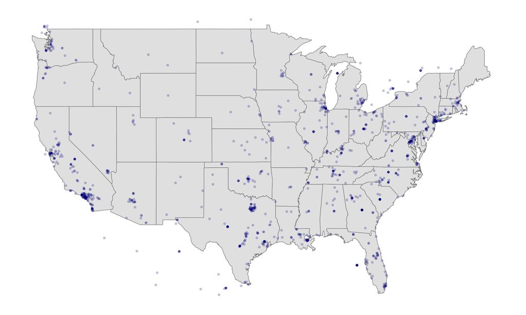

```r
#install.packages("ggplot2")
library(ggplot2)

## First create a data frame with the map data
map.data <- map_data("state")

# And we use ggplot2 to draw the map:
# 1) map base
ggplot(map.data) + geom_map(aes(map_id = region), map = map.data, fill = "grey90",
    color = "grey50", size = 0.25) + expand_limits(x = map.data$long, y = map.data$lat) +
    # 2) limits for x and y axis
    scale_x_continuous(limits=c(-125,-66)) + scale_y_continuous(limits=c(25,50)) +
    # 3) adding the dot for each tweet
    geom_point(data = tweets,
    aes(x = lon, y = lat), size = 1, alpha = 1/5, color = "darkblue") +
    # 4) removing unnecessary graph elements
    theme(axis.line = element_blank(),
        axis.text = element_blank(),
        axis.ticks = element_blank(),
        axis.title = element_blank(),
        panel.background = element_blank(),
        panel.border = element_blank(),
        panel.grid.major = element_blank(),
        panel.grid.minor = element_blank(),
        plot.background = element_blank())
```

Finally, it’s also possible to collect a random sample of tweets. That’s what the “sampleStream” function does:

```r
sampleStream(file.name="tweets_random.json", timeout=30, oauth=my_oauth)
```

```
## Capturing tweets...
## Connection to Twitter stream was closed after 30 seconds with up to 2727 tweets downloaded.
```

Here I’m collecting 30 seconds of tweets. And once again, to open the tweets in R…

```r
tweets <- parseTweets("tweets_random.json")
```

```
## 1109 tweets have been parsed.
```

What is the most retweeted tweet?

```r
tweets[which.max(tweets$retweet_count),]
```

```
##                                                                                         text
## 697 RT @Harry_Styles: @Louis_Tomlinson im sitting on the sofa opposite you....you look sexy.
##     retweet_count favorited truncated             id_str
## 697        340255     FALSE     FALSE 690395155552178177
##     in_reply_to_screen_name
## 697                    <NA>
##                                                                                   source
## 697 <a href="http://twitter.com/download/android" rel="nofollow">Twitter for Android</a>
##     retweeted                     created_at in_reply_to_status_id_str
## 697     FALSE Fri Jan 22 04:46:46 +0000 2016                      <NA>
##     in_reply_to_user_id_str lang listed_count verified location
## 697                    <NA>   en            7    FALSE    32215
##     user_id_str                                                description
## 697  1339570302 he's always smoking when he's out bearding ! est. apr 2013
##     geo_enabled                user_created_at statuses_count
## 697        TRUE Tue Apr 09 16:13:39 +0000 2013          22469
##     followers_count favourites_count protected user_url  name    time_zone
## 697            1669             2189     FALSE     <NA> zaeyn Kuala Lumpur
##     user_lang utc_offset friends_count  screen_name country_code country
## 697        en      28800           560 armoredmalik         <NA>    <NA>
##     place_type full_name place_name place_id place_lat place_lon lat lon
## 697       <NA>      <NA>         NA       NA       NaN       NaN  NA  NA
##     expanded_url  url
## 697         <NA> <NA>
```

What are the most popular hashtags at the moment? We’ll use regular expressions to extract hashtags.

```r
library(stringr)
ht <- str_extract_all(tweets$text, "#(\\d|\\w)+")
ht <- unlist(ht)
head(sort(table(ht), decreasing = TRUE))
```

```
## ht
##    #ALDUBShareTheLOVE #MegaSiTeImportaAMiNo              #fitness
##                    12                     5                     3
##                  #سكس               #Comics        #ConorMcGregor
##                     3                     2                     2
```

How many tweets mention Justin Bieber?

```r
length(grep("bieber", tweets$text, ignore.case=TRUE))
```

```
## [1] 3
```

#### Collecting data from Twitter’s REST API

It is possible to download recent tweets, but only up those less than 7 days old, and in some cases not all of them. We will use the `smappR` package for this (and the other functions that scrape Twitter’s REST API).

```r
#install.packages("devtools")
library(devtools)
#install_github("SMAPPNYU/smappR")
library(smappR)
searchTweets(q="palin", filename="palin-tweets.json",
  n=200, until="2016-01-20",
  oauth_folder="~/git/data-science-workshop/scraping/credentials")
```

```
## 100 tweets. Max id: 689598209291726848
## 176 hits left
## 200 tweets. Max id: 689598183404654592
```

```r
tweets <- parseTweets("palin-tweets.json")
```

```
## 200 tweets have been parsed.
```

You can check the documentation about the options for string search [here](https://dev.twitter.com/rest/public/search).

This is how you would extract information from user profiles:

```r
reps <- c("RealBenCarson", "tedcruz", "CarlyFiorina", "GrahamBlog",
    "GovMikeHuckabee", "GovernorPataki", "RandPaul", "marcorubio",
    "RickSantorum", "bobbyjindal", "GovernorPerry", "realDonaldTrump",
    "JebBush", "GovChristie", "JohnKasich", "ScottWalker",
    "gov_gilmore")
dems <- c('HillaryClinton', 'SenSanders', "MartinOMalley",
    "LincolnChafee", "JimWebbUSA")
candidates <- c(reps, dems)

users <- getUsersBatch(screen_names=candidates,
                       oauth_folder="~/git/data-science-workshop/scraping/credentials")
```

```
## 1--22 users left
```

```r
str(users)
```

```
## 'data.frame':    22 obs. of  14 variables:
##  $ id_str           : chr  "3021632183" "33750798" "113047940" "65691824" ...
##  $ screen_name      : chr  "gov_gilmore" "ScottWalker" "JebBush" "CarlyFiorina" ...
##  $ name             : chr  "Jim Gilmore" "Scott Walker" "Jeb Bush" "Carly Fiorina" ...
##  $ description      : chr  "Candidate for the Republican nomination for President. Former Virginia Governor (1998-2002)." "Husband, father of two, 45th Governor of Wisconsin, reformer, leader & principled conservative." "43rd Governor of Florida. Candidate for President of the United States. \nCo…
##  $ followers_count  : int  2885 221025 426818 649658 775989 24976 1241385 126835 82670 1098347 ...
##  $ statuses_count   : int  1114 7990 3538 3828 8774 1989 13511 12496 2039 2481 ...
##  $ friends_count    : int  1171 212 228 693 424 6061 1910 2056 484 51 ...
##  $ created_at       : chr  "Fri Feb 06 15:50:24 +0000 2015" "Tue Apr 21 01:15:16 +0000 2009" "Wed Feb 10 14:45:07 +0000 2010" "Fri Aug 14 17:50:35 +0000 2009" ...
##  $ location         : chr  "Richmond, VA" "Wauwatosa, WI" "Miami, FL" "Virginia " ...
##  $ lang             : chr  "en" "en" "en" "en" ...
##  $ time_zone        : chr  "Eastern Time (US & Canada)" "Central Time (US & Canada)" "Eastern Time (US & Canada)" "Pacific Time (US & Canada)" ...
##  $ status.id_str    : chr  "690333960971358208" "690207188728573952" "690381961471381505" "690338139785723904" ...
##  $ status.created_at: chr  "Fri Jan 22 00:43:36 +0000 2016" "Thu Jan 21 16:19:51 +0000 2016" "Fri Jan 22 03:54:20 +0000 2016" "Fri Jan 22 01:00:13 +0000 2016" ...
##  $ status.text      : chr  "#Manufacturing successes in Conway, New Hampshire at Tee Enterprises.  Thanks Carl Thibodeau for the tour. https://t.co/Xir5D82"| __truncated__ "Matt and Alex playing at church. #tbt https://t.co/ogYsq7uz2a" "RT @seanhannity: .@JebBush: @HillaryClinton “has not told th…
```

Who is the candidate with the most followers?

```r
users[which.max(users$followers_count),]
```

```
##      id_str     screen_name            name
## 15 25073877 realDonaldTrump Donald J. Trump
##                                                                                                                 description
## 15 The official Twitter profile for Donald J. Trump. #Facebook: https://t.co/MBxJXtWY2h #Instagram: https://t.co/as4SAYnzAW
##    followers_count statuses_count friends_count
## 15         5775432          30368            49
##                        created_at     location lang
## 15 Wed Mar 18 13:46:38 +0000 2009 New York, NY   en
##                     time_zone      status.id_str
## 15 Eastern Time (US & Canada) 690382722162913280
##                 status.created_at
## 15 Fri Jan 22 03:57:22 +0000 2016
##                                                                                                           status.text
## 15 The late, great, William F. Buckley would be ashamed of what had happened to his prize, the dying National Review!
```

Download up to 3,200 recent tweets from a Twitter account:

```r
getTimeline(filename="trump-tweets.json", screen_name="realDonaldTrump",
    n=1000, oauth_folder="~/git/data-science-workshop/scraping/credentials")
```

```
## 196 tweets. Max id: 684844313528942599
## 178 hits left
## 396 tweets. Max id: 680149494214823937
## 177 hits left
## 596 tweets. Max id: 676165531695783936
## 176 hits left
## 796 tweets. Max id: 673515997538684928
## 175 hits left
## 996 tweets. Max id: 669506636092997632
## 174 hits left
## 1196 tweets. Max id: 666050394770898944
```

What are the most common hashtags?

```r
tweets <- parseTweets("trump-tweets.json")
```

```
## 1196 tweets have been parsed.
```

```r
ht <- str_extract_all(tweets$text, "#(\\d|\\w)+")
ht <- unlist(ht)
head(sort(table(ht), decreasing = TRUE))
```

```
## ht
##             #Trump2016 #MakeAmericaGreatAgain             #TeamTrump
##                    143                    104                     14
##                  #FITN             #GOPDebate                 #Trump
##                      9                      8                      8
```

Download friends and followers:

```r
followers <- getFollowers("NYUdatascience",
    oauth_folder="~/git/data-science-workshop/scraping/credentials")
```

```
## /Users/pablobarbera/git/data-science-workshop/scraping/credentials/twitter-token.Rdata
## 15 API calls left
## 975 followers. Next cursor: 0
## 14 API calls left
```

What are the most common words that followers of NYUDataScience use to describe themselves on Twitter?

```r
# extract profile descriptions
users <- getUsersBatch(ids=followers,
    oauth_folder="~/git/data-science-workshop/scraping/credentials")
```

```
## 1--975 users left
## 2--875 users left
## 3--775 users left
## 4--675 users left
## 5--575 users left
## 6--475 users left
## 7--375 users left
## 8--275 users left
## 9--175 users left
## 10--75 users left
```

```r
# create table with frequency of word use
library(RTextTools)
dtm <- create_matrix(users$description[users$description!=""], language = "en", weighting = tm::weightTfIdf)
```

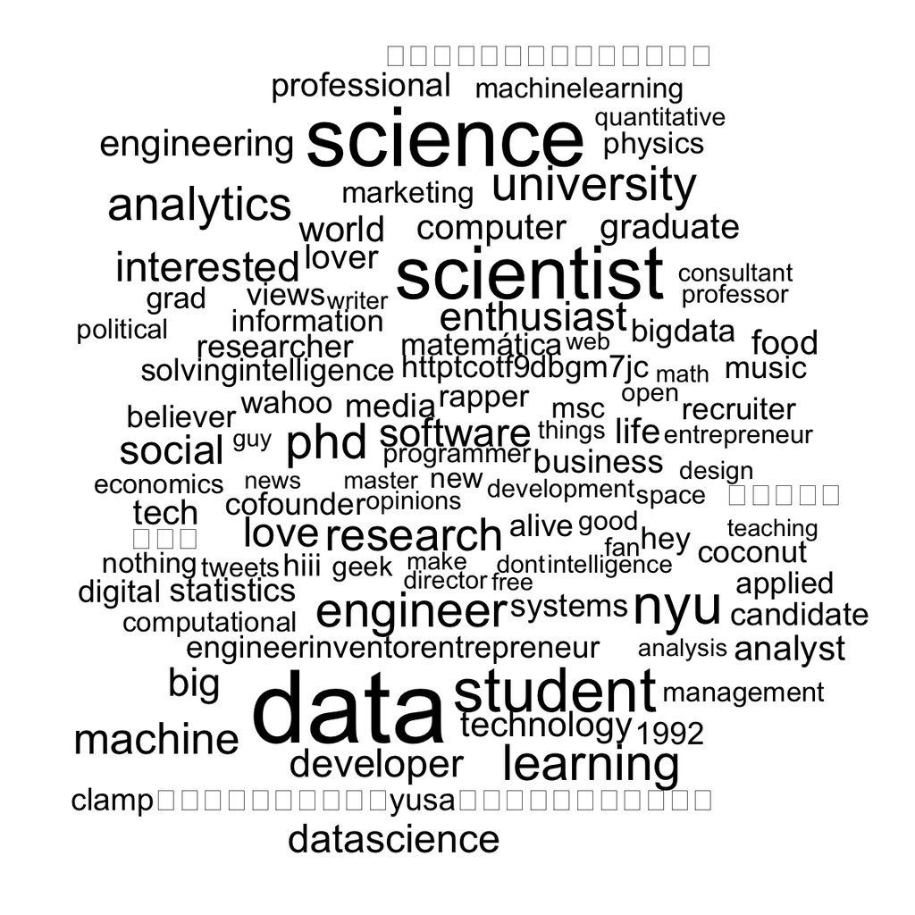

```r
wf <- data.frame(
  word = Terms(dtm),
  freq = apply(dtm, 2, sum) )
wf <- wf[order(wf$freq),]
# create wordcloud
library(wordcloud)
par(mar=c(0,0,0,0))
wordcloud(words = wf$word, freq = wf$freq, max.words = 100, rot.per = 0)
```